# Vancouver Canucks Project

Mae Rennick

2023-07-31

This project looks at the trends and successes of the Vancouver Canucks National Hockey League (NHL) team through time.

This report includes three parts:

1. Statistics through time at the team-level
2. Modeling Vancouver Canucks powerplay success through time
3. Random Forest analysis to identify most influential metrics in determining whether a goal is scored in a given scenario, and determine the best shooter on the Canucks

Data summary and citation:

“NHL Team Statistics.” NHL.com. Nation Hockey League, n.d. Web. July 2013. http://www.nhl.com/.

“NHL Team Stats.” Hockey Stats. Hockeyanalysis.com, 28 Apr. 2013. Web. July 2013. <http://stats.hockeyanalysis.com/teamstats.php?disp=1&db=201213&sit=5v5close&sort= PDO&sortdir=DESC>.

MoneyPuck. https://moneypuck.com/data.htm

### Canucks Team Statistics

This report will be using the following metrics to measure team success through time 2008-2023): - Time on Ice (TOI) - Games Played (GP) - Corsi For = Shot attempts for at even strength: Shots + Blocks + Misses (CF) - Corsi Against = Corsi score of the opposing team (CA) - Goals For (GF) - Penalty minutes served (PENT) - Penalty minutes drawn (PEND) - Saves = blocked shot attempts for (SAVES) - Rebounds (REB) - Shots (SHOTS)

#### Data Wrangling

```r
knitr::opts_chunk$set(echo = TRUE, warning= FALSE, message= FALSE)


# Packages ----
library(tidyverse)    # For data manipulation, plotting, etc.
library(here)    # For reproducible data importation
library(janitor)      # For text data manipulation
library(httr)         # To import data on github
library(TExPosition)  # PCA tools
library(ggrepel)      # Plotting tool for ggplot2
library(kableExtra)   # HTML table tools
library(RColorBrewer) # plotting colors
library(gridExtra)    # Plotting tools
library(dplyr)
library(magrittr)
library(corrplot)
library(tidyr)
library(ranger)
library(vip)
library(caret)
library(broom)


# Custom functions ----
# nice_table() simplifies the printing of HTML tables using kable
nice_table <- function(x){

  kable(x) %>%
    kable_styling(bootstrap_options = c('striped', 'hover', 'responsive', 'condensed'))

}

# Color palettes ----
rdgy <- brewer.pal(n = 11, name = "RdGy") # display.brewer.pal(11, "RdGy")

# ggplot2 finishings
pca_furnish <- theme_classic() +
  theme(axis.title = element_blank(),
        axis.ticks = element_blank(),
        axis.line = element_blank()
        )
```

```r
## Import Data

canucks_2009<- read_csv(here("MP_data", "skaters_2008_2009.csv")) %>%
  mutate(season= "2008-2009")
canucks_2010<- read_csv(here("MP_data", "skaters_2009_2010.csv")) %>%
  mutate(season= "2009-2010")
canucks_2011<- read_csv(here("MP_data", "skaters_2010_2011.csv")) %>%
  mutate(season= "2010-2011")
canucks_2012<- read_csv(here("MP_data", "skaters_2011_2012.csv")) %>%
  mutate(season= "2011-2012")
canucks_2013<- read_csv(here("MP_data", "skaters_2012_2013.csv")) %>%
  mutate(season= "2012-2013")
canucks_2014<- read_csv(here("MP_data", "skaters_2013_2014.csv")) %>%
  mutate(season= "2013-2014")
canucks_2015<- read_csv(here("MP_data", "skaters_2014_2015.csv")) %>%
  mutate(season= "2014-2015")
canucks_2016<- read_csv(here("MP_data", "skaters_2015_2016.csv")) %>%
  mutate(season= "2015-2016")
canucks_2017<- read_csv(here("MP_data", "skaters_2016_2017.csv")) %>%
  mutate(season= "2016-2017")
canucks_2018<- read_csv(here("MP_data", "skaters_2017_2018.csv")) %>%
  mutate(season= "2017-2018")
canucks_2019<- read_csv(here("MP_data", "skaters_2018_2019.csv")) %>%
  mutate(season= "2018-2019")
canucks_2020<- read_csv(here("MP_data", "skaters_2019_2020.csv")) %>%
  mutate(season= "2019-2020")
canucks_2021<- read_csv(here("MP_data", "skaters_2020_2021.csv")) %>%
  mutate(season= "2020-2021")
canucks_2022<- read_csv(here("MP_data", "skaters_2021_2022.csv")) %>%
  mutate(season= "2021-2022")
canucks_2023<- read_csv(here("MP_data", "skaters_2022_2023.csv")) %>%
  mutate(season= "2022-2023")



canucks_skater_data<- rbind(canucks_2009, canucks_2010, canucks_2011, canucks_2012, canucks_2013, canucks_2014, canucks_2015, canucks_2016, canucks_2017, canucks_2018, canucks_2019, canucks_2020, canucks_2021, canucks_2022, canucks_2023) %>%
  filter(team== "VAN")




shots_2007<- read_csv(here("MP_data", "CAN_shots_2007.csv"))
shots_2008<- read_csv(here("MP_data", "CAN_shots_2008.csv"))
shots_2009<- read_csv(here("MP_data", "CAN_shots_2009.csv"))
shots_2010<- read_csv(here("MP_data", "CAN_shots_2010.csv"))
shots_2011<- read_csv(here("MP_data", "CAN_shots_2011.csv"))
shots_2012<- read_csv(here("MP_data", "CAN_shots_2012.csv"))
shots_2013<- read_csv(here("MP_data", "CAN_shots_2013.csv"))
shots_2014<- read_csv(here("MP_data", "CAN_shots_2014.csv"))
shots_2015<- read_csv(here("MP_data", "CAN_shots_2015.csv"))
shots_2016<- read_csv(here("MP_data", "CAN_shots_2016.csv"))
shots_2017<- read_csv(here("MP_data", "CAN_shots_2017.csv"))
shots_2018<- read_csv(here("MP_data", "CAN_shots_2018.csv"))
shots_2019<- read_csv(here("MP_data", "CAN_shots_2019.csv"))
shots_2020<- read_csv(here("MP_data", "CAN_shots_2020.csv"))[, colnames(shots_2019)]
shots_2021<- read_csv(here("MP_data", "CAN_shots_2021.csv"))
shots_2022<- read_csv(here("MP_data", "CAN_shots_2022.csv"))

shot_data<- rbind(shots_2009, shots_2010, shots_2011, shots_2012, shots_2013, shots_2014, shots_2015, shots_2016, shots_2017, shots_2018, shots_2019, shots_2020, shots_2021, shots_2022)

canucks_shot_data<- shot_data %>%
  filter(homeTeamCode== "VAN" | awayTeamCode == "VAN")


file_path <- "/Users/maerennick/GitHub/NHL project/Vancouver_Canucks_Project/MP_data/teams_2007_2016.csv"

teams_2007_2016<- read.csv(file_path)

file_path_2 <- "/Users/maerennick/GitHub/NHL project/Vancouver_Canucks_Project/MP_data/teams_2017.csv"

teams_2017_2023<- read.csv(file_path_2)

nhl_team_data <- rbind(teams_2007_2016, teams_2017_2023)
```

```r
## Data Preparation

canucks_data <-  nhl_team_data %>%
  clean_names() %>%
  dplyr::filter(player_team == "VAN") %>% ## include only Vancouver (for and against)
  select(team:situation, corsi_percentage, ice_time, shots_on_goal_for:rebound_goals_for, penalties_for, penality_minutes_for, x_on_goal_for) %>%
  rename(penalties_served= penalties_for) %>%
  rename(penality_minutes_served= penality_minutes_for) %>%
  select(-opposing_team)


against_canucks_data<- nhl_team_data %>%
  clean_names() %>%
  dplyr::filter(opposing_team == "VAN") %>%
    select(team, game_id, situation, corsi_percentage, ice_time, shots_on_goal_for:rebound_goals_for, penalties_for, penality_minutes_for, x_on_goal_for) %>%
  rename(opposing_team= team) %>%
  rename(opposing_corsi_percentage= corsi_percentage) %>%
  rename(opposing_ice_time= ice_time) %>%
  rename(opposing_shots_on_goal= shots_on_goal_for) %>%
  rename(opposing_missed_shots= missed_shots_for) %>%
  rename(opposing_blocked_shot_attempts= blocked_shot_attempts_for) %>%
  rename(opposing_shot_attempts= shot_attempts_for) %>%
  rename(opposing_goals= goals_for) %>%
  rename(opposing_rebounds= rebounds_for) %>%
  rename(opposing_rebound_goals= rebound_goals_for) %>%
  rename(penalties_drawn= penalties_for) %>%
  rename(penality_minutes_drawn= penality_minutes_for) %>%
  rename(opposing_x_on_goal= x_on_goal_for)


canucks_team_data<- canucks_data %>%
  right_join(against_canucks_data, by=c("game_id","situation")) %>%
  select(-opposing_shot_attempts) %>%
  select(-opposing_rebounds) %>%
  select(-opposing_x_on_goal) %>%
  select(-opposing_blocked_shot_attempts) %>%
  select(-opposing_missed_shots) %>%
  filter(situation== "5on5") %>%
  group_by(season) %>%
  mutate(GP= n_distinct(game_id)) %>% # games played
  rename(TOI= ice_time) %>%
  rename(CF= corsi_percentage) %>%
  rename(CA= opposing_corsi_percentage) %>%
  rename(GF=goals_for) %>%
  rename(GA=opposing_goals) %>%
  rename(PENT= penality_minutes_served) %>%
  rename(PEND= penality_minutes_drawn) %>%
  rename(SHOTS=shots_on_goal_for) %>%
  rename(SAVES= blocked_shot_attempts_for) %>%
  rename(REB= rebounds_for)


canucks_team_data_avg<- canucks_team_data %>%
  group_by(season) %>%
  summarise(across(where(is.numeric), mean, na.rm = TRUE))

# Print data
#kable(canucks_team_data) %>%
    #kable_styling(bootstrap_options = c('striped', 'hover', 'responsive', 'condensed'))
```

##### Calculate Z-Scores

1. Adjust all scores by the number of games played due to a shorted 2012-2013 and 2020-2021 seasons
2. Compute z-scores of all measures to facilitate comparisons

```r
canucks_team_data$GP <- as.numeric(canucks_team_data$GP)
canucks_team_data$season <- as.numeric(canucks_team_data$season)

# Pre-processes, adjusts, and z-scores canucks data ----
canucks_data_long <- canucks_team_data_avg %>%
  dplyr::select( -game_date, -game_id, -opposing_ice_time, -missed_shots_for, -opposing_shots_on_goal,-rebound_goals_for, -missed_shots_for, -x_on_goal_for, -penalties_served, -penalties_drawn, -opposing_rebound_goals, -shot_attempts_for) %>%
  gather(Meas, Val, -season, -GP) %>%
  group_by(Meas) %>%
  mutate(Val_Adj = Val/GP,               # adjusts based on games played
         Val_Zscore = scale(Val_Adj)     # computes z-scores
         ) %>%
  ungroup() %>%
  mutate(sig = factor(ifelse(abs(Val_Zscore) > 1.96, "p < .05", "p > .05"))) # z score > 1.96
```

##### Performance across seasons

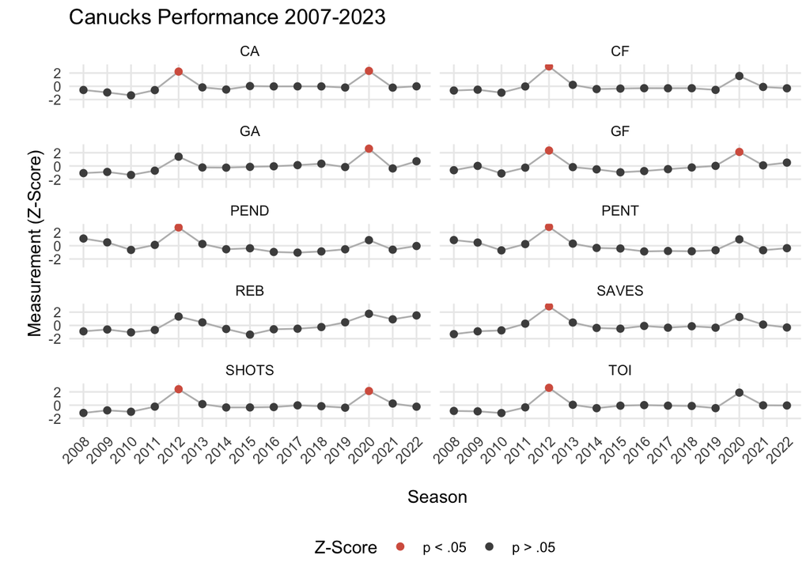

```r
ggplot(canucks_data_long, aes(factor(season), Val_Zscore)) +
  geom_path(aes(group = 1), color = rdgy[8]) +
  geom_point(aes(color = sig), size = 1.75) +
  scale_color_manual(values = c(rdgy[3], rdgy[10]), name = "Z-Score") +
  scale_y_continuous(breaks = c(-2, 0, 2), minor_breaks = NULL) +
  coord_cartesian(ylim = c(-3,3)) +
  theme_minimal() +
  labs(x = "\n Season",
       y = "\n Measurement (Z-Score)",
       title = "Canucks Performance 2007-2023"
       ) +
  theme(axis.text.x = element_text(angle = 45, hjust = 1),
        legend.position = "bottom"
        )+
  facet_wrap(~Meas, nrow = 5)
```

For the Vancouver Canucks, several performance metrics peaked in 2012 season. The 2012–13 Vancouver Canucks season was the team’s 43rd season in the National Hockey League and the Canucks won their fifth-straight Northwest Division title but finished third in the Western Conference. Corsi scores against and the amount of penalties served additionally peaked that year suggesting that they were facing strong competition. The 2020 season was additionally significant. This season was unconventional due to the COVID-19 shutdowns, which is likely why there is no peak in time on ice and could result in false peask due to the few numbers of games that were played.

##### Correlations

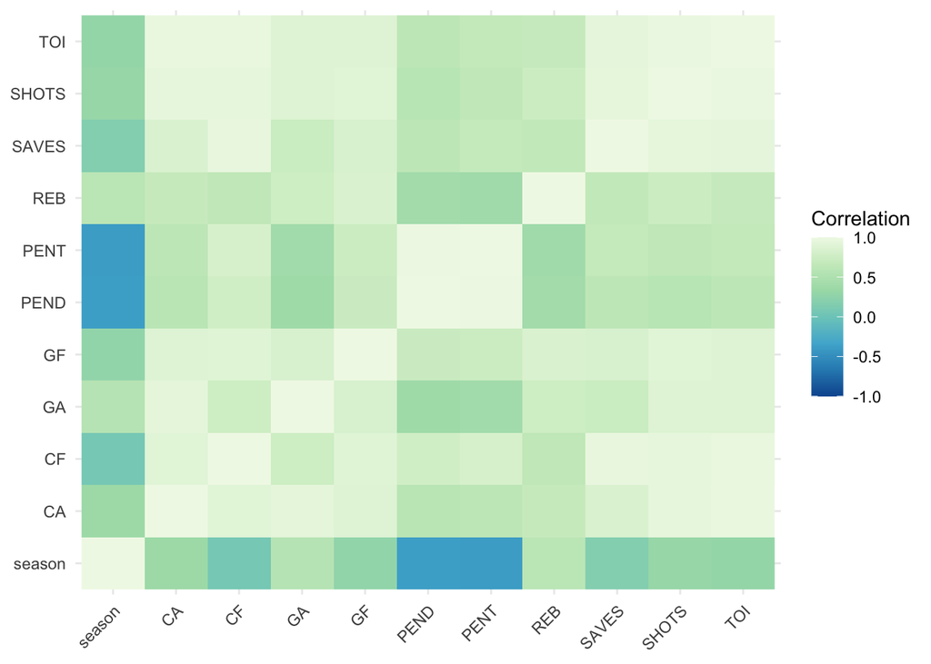

```r
# Converts back to wide format

canucks_data_wide <- canucks_team_data %>%
  dplyr::select(-team, -name, -player_team, -home_or_away, -game_date, -position, -situation, -opposing_team, -opposing_ice_time, -missed_shots_for, -opposing_shots_on_goal,-rebound_goals_for, -missed_shots_for, -x_on_goal_for, -penalties_served, -penalties_drawn, -opposing_rebound_goals, -shot_attempts_for, -game_id) %>%
  group_by(season) %>%
  mutate(CF= mean(CF)) %>%
  mutate(TOI= mean(TOI)) %>%
  mutate(SHOTS= mean(SHOTS)) %>%
  mutate(SAVES= mean(SAVES)) %>%
  mutate(GF= mean(GF)) %>%
  mutate(REB= mean(REB)) %>%
  mutate(PENT= mean(PENT)) %>%
  mutate(CA= mean(CA)) %>%
  mutate(GA= mean(GA)) %>%
  mutate(PEND= mean(PEND)) %>%
  mutate(GP= mean(GP)) %>%
  gather(Meas, Val, -season, -GP) %>%
  group_by(Meas) %>%
  mutate(Val_Adj = Val/GP,               # adjusts based on games played
         Val_Zscore = scale(Val_Adj)     # computes z-scores
         ) %>%
  ungroup() %>%
  mutate(sig = factor(ifelse(abs(Val_Zscore) > 1.96, "p < .05", "p > .05"))) %>%  # z score > 1.96
  select(season, Meas, Val_Zscore) %>%
  unique()%>%
  spread(Meas, Val_Zscore)

# Computes correlations
canucks_cors <- cor(canucks_data_wide)

# Correlations to long format for plotting
canucks_cors_long <- canucks_cors %>%
  reshape2::melt() %>%
  arrange(Var1, Var2)

# Correlation heatmap
ggplot(canucks_cors_long, aes(x = Var1, y = Var2, fill = value)) +
  geom_raster() +
  theme_minimal() +
  theme(axis.text.x = element_text(angle = 45, hjust = 1),
        axis.title = element_blank()
        ) +
  scale_fill_distiller(palette = "GnBu",
                       limits = c(-1, 1),
                       name = "Correlation"
                       )
```

### Powerplay Analysis

A “powerplay” is a sporting term used to describe a period of play where one team has a numerical advantage in players, usually due to a rule violation by the opposing team. In Hockey, they are considered to be a prime opportunity for scoring. Particularly for the Vancouver Canucks, successful powerplays, resulting in a goal, is considered to be a main reason for the team’s success.

##### Read about: [Five key Canucks are contributing to power play success](https://thecanuckway.com/2019/11/27/five-key-canucks-contributing-powerplay-success/)

To take a deeper look into the success and performance of the Canucks team through time, we will analyze power plays and how goal scoring during power play opportunities have changed through time.

This is an extension of the work done by [Ekarin Pongpipat & Matthew J. Kmiecik, 2018](https://mattkmiecik.com/posts/post-Multilevel-Modeling-in-R-with-NHL-Power-Play-Data/post-Multilevel-Modeling-in-R-with-NHL-Power-Play-Data.html)

First we will look across the entire NHL:

```r
pp<- nhl_team_data %>%
  filter(situation == "5on4")

# Initializing variables to store team names
pacific <- c('S.J', 'CGY', 'L.A', 'ANA', 'EDM', 'VAN', 'ARI')
central <- c('ATL.WPG', 'NSH', 'STL', 'DAL', 'COL', 'MIN', 'CHI')
metropolitan <- c('WSH', 'N.J', 'PHI', 'CBJ', 'PIT', 'NYR', 'NYI', 'CAR')
atlantic <- c('T.B', 'BOS', 'TOR', 'DET', 'MTL', 'FLA', 'OTT', 'BUF')

# Creating a column to identify each team's division
pp <- pp %>%
  mutate(
    division = case_when(
      pp$team %in% pacific ~ 'Pacific',
      pp$team %in% central ~ 'Central',
      pp$team %in% metropolitan ~ 'Metropolitan',
      pp$team %in% atlantic ~ 'Atlantic')
    )

divisions <-
  data.frame(
    Pacific = c(pacific, ''),
    Central = c(central, ''),
    Metropolitan = metropolitan,
    Atlantic = atlantic
    )
```

##### NHL Divisions

```r
# Prints table
kable(divisions) %>%
  kable_styling(bootstrap_options = c('striped', 'hover', 'responsive'))
```

| Pacific | Central | Metropolitan | Atlantic |
| --- | --- | --- | --- |
| S.J | ATL.WPG | WSH | T.B |
| CGY | NSH | N.J | BOS |
| L.A | STL | PHI | TOR |
| ANA | DAL | CBJ | DET |
| EDM | COL | PIT | MTL |
| VAN | MIN | NYR | FLA |
| ARI | CHI | NYI | OTT |
|  |  | CAR | BUF |

```r
pp_season<- pp %>%
  group_by(team, season) %>%
  summarise(games_played= n_distinct(gameId), division, goalsFor= sum(goalsFor))
```

##### Average powerplay goals across divisions

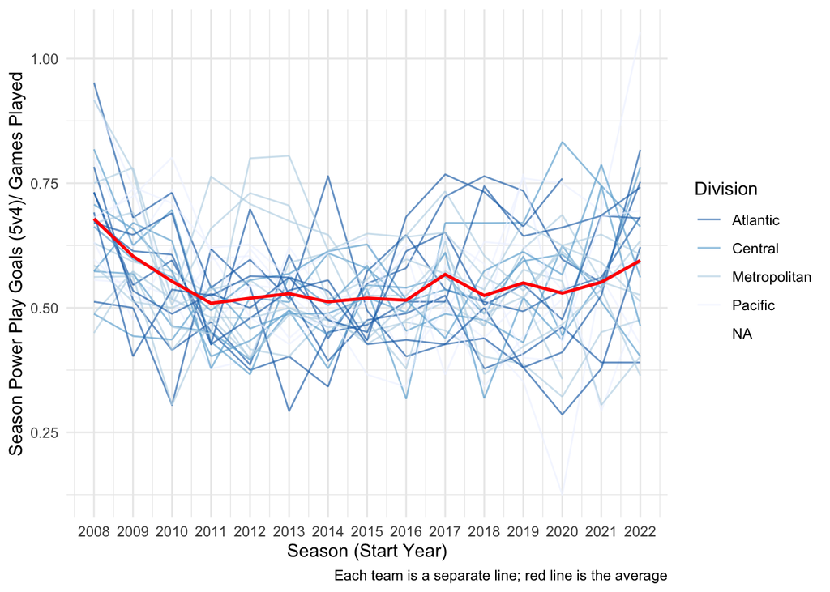

```r
ggplot(pp_season, aes(season, goalsFor/games_played, group = 1)) +
  geom_line(aes(group = team, color = division), alpha = 2/3) +
  geom_line(stat = 'summary', fun.y = 'mean', size = .9, color = 'red') +
  scale_color_brewer(palette = 'Blues', direction = -1) +
  labs(x = 'Season (Start Year)',
       y = 'Season Power Play Goals (5v4)/ Games Played',
       caption = 'Each team is a separate line; red line is the average') +
  guides(color = guide_legend(title = 'Division')) +
  scale_x_continuous(limits = c(2008, 2022), breaks = c(2008:2022)) +
  theme_minimal()
```

There is a lot of variation across power play success through time across teams and across divisions. On average, success appears to be relatively consistent through time with the exception of the steep dip in the first few seasons. This could be due to improved team strategy, defense and/or goalie ability through time.

#### Model powerplay success through time

We’ll use these omnibus estimates to examine all regression models simultaneously via R2 estimates. These allow us to see how much variability in powerplay goals per games played was explained by time:

```r
modTeam <-
  pp_season %>%
  ungroup() %>%
  nest_by(team) %>%
  mutate(level1 = list(lm((goalsFor/games_played) ~ season, data = data)))

level1Omni <-
  modTeam %>%
  summarise(broom::glance(level1)) %>%
  ungroup() %>%
  mutate(sig = p.value < .05) %>%
  filter(team != "LAK", team != "NJD", team != "SEA", team != "SJS", team != "TBL") ## omitting teams that do not have enough data
```

##### Significance of Regressions

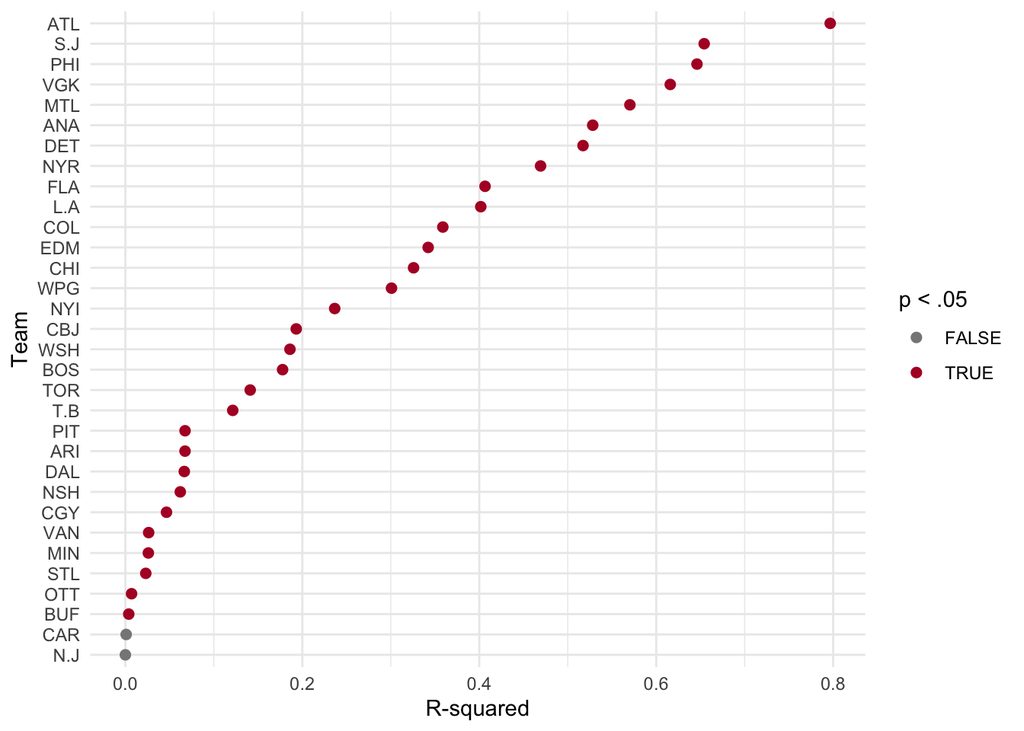

```r
# Color palette
sigColorPal <- brewer.pal(11,'RdGy') # display.brewer.pal(11,'RdGy')

# R^2 Plot
ggplot(level1Omni, aes(r.squared, reorder(team, r.squared), color = sig)) +
  geom_point(size = 2) +
  scale_color_manual(values = sigColorPal[c(9,2)]) +
  labs(x = 'R-squared', y = 'Team') +
  guides(color = guide_legend(title = 'p < .05')) +
  theme_minimal()
```

```r
## all but 2 are significantly different from 0
```

All but two of the regressions are significant, with Atlanta having the strongest relationship between powerplay success and time. While significant, the Vancouver cnaucks have a lower R^2 value suggesting there is a lot of variability in the data that cannot be explained or predicted by the regression.

##### Directionality of trends in powerplay success through time across teams

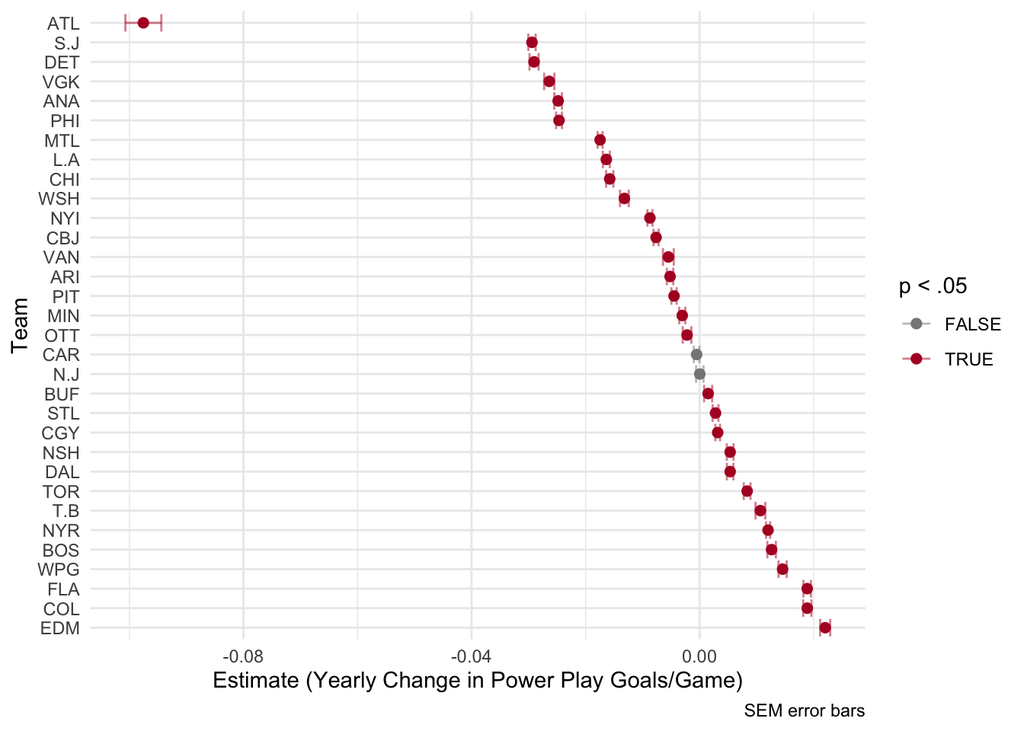

```r
# Extracting level 1 coefficients
level1Coef <-
  modTeam %>%
  summarise(broom::tidy(level1)) %>%
  ungroup() %>%
  filter(term == 'season') %>%   # Facilitates plotting
  mutate(sig = p.value < .05) %>%
  filter(team != "LAK", team != "NJD", team != "SEA", team != "SJS", team != "TBL") ## omitting teams that do not have enough data


ggplot(level1Coef, aes(estimate, reorder(team, -1*estimate), color = sig)) +
  geom_point(size = 2) +
  geom_errorbarh(
    aes(xmin = estimate - std.error, xmax = estimate + std.error),
    alpha = 1/2
    ) +
  scale_color_manual(values = sigColorPal[c(9,2)]) +
  labs(
    x = 'Estimate (Yearly Change in Power Play Goals/Game)',
    y = 'Team',
    caption = 'SEM error bars'
    ) +
  guides(color = guide_legend(title = 'p < .05')) +
  theme_minimal()
```

This figure looks at the directionality of powerplay success through time. Atlanta had the best fitting model and additionally has the most negative correlation, suggesting that there powerplay success has gone down significantly through time. The Vancouver Canucks have one of the shallower rates of change, but exhibit a negative trajectory in powerplay success through time.

##### Trends in Canucks powerplay success through time

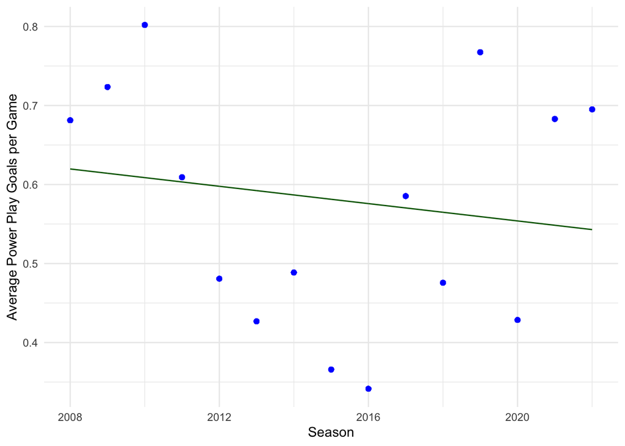

```r
model_data <- pp_season %>%
  filter(team == "VAN") %>%
  mutate(goalsFor_per_game = goalsFor / games_played) %>%
  lm(goalsFor_per_game ~ season, data = .)

model_data <- model_data %>%
  augment() %>%
  mutate(fitted_values = .fitted)

ggplot(model_data, aes(x = season, y = goalsFor_per_game)) +
  geom_point(color = "blue") +  # Data points
  geom_line(aes(y = fitted_values), color = "darkgreen") +  # Fitted regression line
  labs(
       x = "Season",
       y = "Average Power Play Goals per Game") +
  theme_minimal()
```

As predicted by the R^2 value, there is a lot of variation in the data that is not well described by the model. However, we do see a decline in powerplay success on average through time.

### Random Forest: scoring for the Vancouver Canucks

Random Forest is a powerful machine learning algorithm that can be used to predict outcomes, such as whether a goal is scored or not, based on a set of input features or metrics.

#### Determining the accuracy of the random forest

```r
can_shot_data<- shot_data %>%
  filter(homeTeamCode=="VAN") %>%
  select(goal, season, isHomeTeam, shooterName, period, homeTeamGoals, awayTeamGoals, shotAngleAdjusted, xCordAdjusted, yCordAdjusted, shotDistance, shotType, shotOnEmptyNet, playerPositionThatDidEvent, shooterTimeOnIce)

# Check for missing values in each column
missing_values <- colSums(is.na(can_shot_data))

# Print columns with missing values
#print(missing_values[missing_values > 0])

# Remove rows with missing values
can_shot_data <- na.omit(can_shot_data) ## remvoing NAs --> there is enough data to make up for it

goal_rf<- randomForest::randomForest(as.factor(goal) ~season + isHomeTeam+ period+ homeTeamGoals+ awayTeamGoals+ shotAngleAdjusted+ xCordAdjusted+ yCordAdjusted+ shotDistance+ shotType+ shotOnEmptyNet+ playerPositionThatDidEvent+ shooterTimeOnIce, data= can_shot_data)

goal_rf
```

```
##
## Call:
##  randomForest(formula = as.factor(goal) ~ season + isHomeTeam +      period + homeTeamGoals + awayTeamGoals + shotAngleAdjusted +      xCordAdjusted + yCordAdjusted + shotDistance + shotType +      shotOnEmptyNet + playerPositionThatDidEvent + shooterTimeOnIce,      data = can_shot_data)
##                Type of random forest: classification
##                      Number of trees: 500
## No. of variables tried at each split: 3
##
##         OOB estimate of  error rate: 6.56%
## Confusion matrix:
##       0   1 class.error
## 0 44184  65  0.00146896
## 1  3047 118  0.96271722
```

##### Importance of parameters in determining goal success

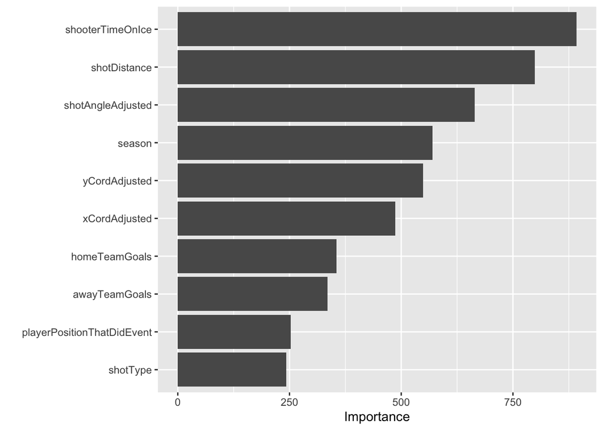

```r
vip_goal_rf<- vip(goal_rf)

vip(goal_rf)
```

Interestingly, time on ice was the most important determinor in goal success, followed by distance of shot. This suggests that the stamina and/or fatigue of the palyer is even more important than where they are on the ice and how far away they are from the net.

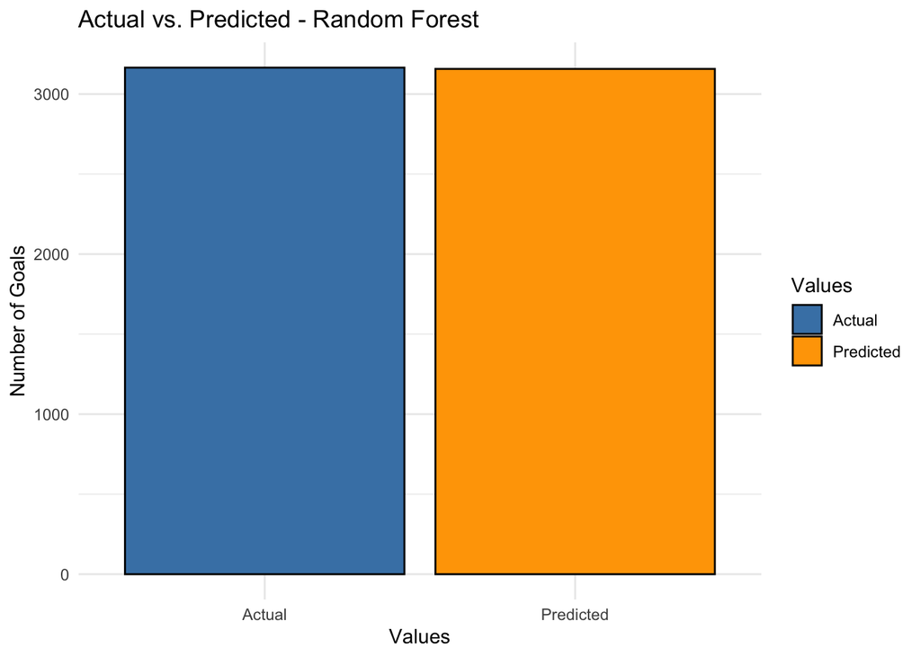

```r
actual_values <- as.numeric(as.character(can_shot_data$goal))
predicted_values <- as.numeric(as.character(predict(goal_rf, can_shot_data)))

# Create a data frame to combine actual and predicted values
data_plot <- data.frame(
  Values = c("Actual", "Predicted"),
  Goals = c(sum(actual_values), sum(predicted_values))
)

# Create the ggplot figure as a grouped bar plot
ggplot(data_plot, aes(x = Values, y = Goals, fill = Values)) +
  geom_bar(stat = "identity", position = "dodge", color = "black") +
  labs(title = "Actual vs. Predicted - Random Forest",
       x = "Values",
       y = "Number of Goals") +
  scale_fill_manual(values = c("Actual" = "steelblue", "Predicted" = "orange")) +
  theme_minimal()
```

### Best Shooters on the Canucks Ranked

```r
goal_preds<- predict(goal_rf, type= "prob")

goal_preds_joined <- cbind(can_shot_data, goal_preds)

rankings<- goal_preds_joined %>%
  mutate(goal_oe = goal- `1`) %>% #goals over expected
  group_by(shooterName) %>%
  summarize(goals_oe_made = sum(goal_oe)) %>%
  arrange(-goals_oe_made) %>%
  rename("Goals Made Over Expectation" = goals_oe_made) %>%
  rename("Shooter Name" = shooterName)

kable(head(rankings)) %>%
    kable_styling(bootstrap_options = c('striped', 'hover', 'responsive', 'condensed'))
```

| Shooter Name | Goals Made Over Expectation |
| --- | --- |
| Jannik Hansen | 9.943580 |
| Elias Pettersson | 9.496948 |
| Mikael Samuelsson | 7.477303 |
| Sven Baertschi | 7.014584 |
| Andrei Kuzmenko | 6.930609 |
| Alexander Edler | 5.873543 |